# Lab 4: Data Visualization and EDA

#### CPE232 Data Models

1. Load all Superstore datasets.

*Note: The same datasets used in Lab 3*

```python
import pandas as pd
import numpy as np
import matplotlib.pyplot as plt
import seaborn as sns
import plotly.express as px
```

```python
# Write your code here
superstore_order = pd.read_csv('superstore/superstore_order.csv')
superstore_people = pd.read_csv('superstore/superstore_people.csv')
superstore_return = pd.read_csv('superstore/superstore_return.csv')
```

2. Determine shape of each dataset (print out the results as well).

```python
# Write your code here
print(superstore_order.shape)
print(superstore_people.shape)
print(superstore_return.shape)
```

```
(8880, 21)
(4, 2)
(296, 2)
```

3. Show information of the dataset.

```python
# Write your code here (superstore_order)
superstore_order.info()
```

```
<class 'pandas.core.frame.DataFrame'>
RangeIndex: 8880 entries, 0 to 8879
Data columns (total 21 columns):
 #   Column         Non-Null Count  Dtype
---  ------         --------------  -----
 0   Row ID         8880 non-null   int64
 1   Order ID       8880 non-null   object
 2   Order Date     8880 non-null   object
 3   Ship Date      8880 non-null   object
 4   Ship Mode      8880 non-null   object
 5   Customer ID    8880 non-null   object
 6   Customer Name  8880 non-null   object
 7   Segment        8880 non-null   object
 8   Country        8880 non-null   object
 9   City           8880 non-null   object
 10  State          8880 non-null   object
 11  Postal Code    8880 non-null   int64
 12  Region         8880 non-null   object
 13  Product ID     8880 non-null   object
 14  Category       8880 non-null   object
 15  Sub-Category   8880 non-null   object
 16  Product Name   8880 non-null   object
 17  Sales          8880 non-null   float64
 18  Quantity       8880 non-null   int64
 19  Discount       8880 non-null   float64
 20  Profit         8880 non-null   float64
dtypes: float64(3), int64(3), object(15)
memory usage: 1.4+ MB
```

```python
# Write your code here (superstore_people)
superstore_people.info()
```

```
<class 'pandas.core.frame.DataFrame'>
RangeIndex: 4 entries, 0 to 3
Data columns (total 2 columns):
 #   Column  Non-Null Count  Dtype
---  ------  --------------  -----
 0   Person  4 non-null      object
 1   Region  4 non-null      object
dtypes: object(2)
memory usage: 196.0+ bytes
```

```python
# Write your code here (superstore_return)
superstore_return.info()
```

```
<class 'pandas.core.frame.DataFrame'>
RangeIndex: 296 entries, 0 to 295
Data columns (total 2 columns):
 #   Column    Non-Null Count  Dtype
---  ------    --------------  -----
 0   Returned  296 non-null    object
 1   Order ID  296 non-null    object
dtypes: object(2)
memory usage: 4.8+ KB
```

4. Are there any missing values? If so, in which column?

Ans: ไม่มีค่า Missing Values (Null) ในทุกคอลัมน์ของทั้ง 3 DataFrames

```python
superstore_order.isnull().sum()
```

```
Row ID           0
Order ID         0
Order Date       0
Ship Date        0
Ship Mode        0
Customer ID      0
Customer Name    0
Segment          0
Country          0
City             0
State            0
Postal Code      0
Region           0
Product ID       0
Category         0
Sub-Category     0
Product Name     0
Sales            0
Quantity         0
Discount         0
Profit           0
dtype: int64
```

```python
superstore_people.isnull().sum()
```

```
Person    0
Region    0
dtype: int64
```

```python
superstore_return.isnull().sum()
```

```
Returned    0
Order ID    0
dtype: int64
```

- 5.1 List unique segments
- 5.2 List unique segments and their corresponding count
- 5.3 Create a pie chart to demonstrate unique segments and their count
- 5.4 Briefly describe what could be interpreted from this pie chart

*Note: please create additional cells to answer 5.2 - 5.3*

```python
# Write your code here (5.1 List unique segments)
print("Unique Segments:", superstore_order["Segment"].unique())
```

```
Unique Segments: ['Consumer' 'Corporate' 'Home Office']
```

```python
# Write your code here (5.2 List unique segments and their corresponding count)
segment_counts = pd.crosstab(superstore_order['Segment'], columns='count').reset_index()
segment_counts
```

| col_0 | Segment | count |
| --- | --- | --- |
| 0 | Consumer | 4613 |
| 1 | Corporate | 2673 |
| 2 | Home Office | 1594 |

```python
# Write your code here (5.3 Create a pie chart)
fig = px.pie(segment_counts, values='count', names='Segment', title='Segment Distribution', )
fig.show()
```

[output not shown]

- 6.1 List unique states
- 6.2 List top-10 unique states and their corresponding count
- 6.3 Create a bar chart (vertical) to demonstrate the count of top-10 unique states
- 6.4 Based on 6.2, also include the total sales of these states (show your result as a dataframe)
- 6.5 Using the result from 6.4, if you were the owner of this superstore, what information could be interpreted from this result?

*Note: please create additional cells to answer 6.2 - 6.4*

```python
# Write your code here (6.1 List unique states)
print("Unique States:", superstore_order["State"].unique())
```

```
Unique States: ['Kentucky' 'California' 'Florida' 'North Carolina' 'Washington' 'Texas'
 'Wisconsin' 'Utah' 'Nebraska' 'Pennsylvania' 'Illinois' 'Minnesota'
 'Michigan' 'Delaware' 'Indiana' 'New York' 'Arizona' 'Virginia'
 'Tennessee' 'Alabama' 'South Carolina' 'Oregon' 'Colorado' 'Iowa' 'Ohio'
 'Missouri' 'Oklahoma' 'New Mexico' 'Louisiana' 'Connecticut' 'New Jersey'
 'Massachusetts' 'Georgia' 'Nevada' 'Rhode Island' 'Mississippi'
 'Arkansas' 'Montana' 'New Hampshire' 'Maryland' 'District of Columbia'
 'Kansas' 'Vermont' 'Maine' 'South Dakota' 'Idaho' 'North Dakota'
 'Wyoming' 'West Virginia']
```

```python
# Write your code here (6.2 List top-10 unique states and their corresponding count)
top10_state = pd.crosstab(superstore_order['State'], columns='count')\
                .sort_values('count', ascending=False).head(10).reset_index()
top10_state
```

| col_0 | State | count |
| --- | --- | --- |
| 0 | California | 1754 |
| 1 | New York | 1001 |
| 2 | Texas | 860 |
| 3 | Pennsylvania | 531 |
| 4 | Washington | 452 |
| 5 | Illinois | 427 |
| 6 | Ohio | 396 |
| 7 | Florida | 339 |
| 8 | Michigan | 230 |
| 9 | North Carolina | 229 |

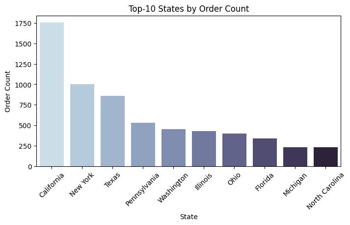

```python
# Write your code here (6.3 Create a bar chart vertical to demonstrate the count of top-10 unique states)
plt.figure(figsize=(8, 4))
sns.barplot(top10_state, x='State', y='count', hue='State',
            palette=sns.color_palette("ch:s=.25,rot=-.25", n_colors=len(top10_state)))
plt.title("Top-10 States by Order Count")
plt.xlabel("State")
plt.ylabel("Order Count")
plt.xticks(rotation=45)
plt.show()
```

```python
# Write your code here (6.4 Based on 6.2, also include the total sales of these states, show your result as a dataframe)
top10_state_sales = superstore_order.groupby("State").agg({'Sales': 'sum', 'State': 'count'})\
                                    .sort_values('Sales', ascending=False).head(10)\
                                    .rename(columns={'Sales': 'total_sales', 'State': 'count'})
top10_state_sales
```

| State | total_sales | count |
| --- | --- | --- |
| California | 399195.4555 | 1754 |
| New York | 274866.8190 | 1001 |
| Texas | 147855.0282 | 860 |
| Washington | 124497.7780 | 452 |
| Pennsylvania | 103852.5210 | 531 |
| Florida | 84083.0880 | 339 |
| Illinois | 71456.1780 | 427 |
| Ohio | 67924.2140 | 396 |
| Virginia | 64632.5200 | 191 |
| Michigan | 62147.6960 | 230 |

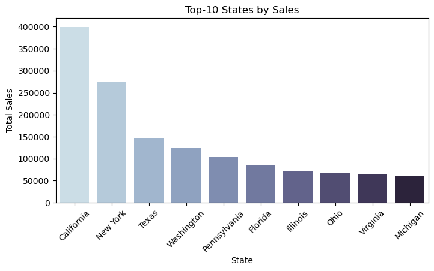

```python
plt.figure(figsize=(8, 4))
sns.barplot(top10_state_sales, x=top10_state_sales.index, y='total_sales',
            hue='State', palette=sns.color_palette("ch:s=.25,rot=-.25", n_colors=len(top10_state)),
            legend=False)
plt.title("Top-10 States by Sales")
plt.xlabel("State")
plt.ylabel("Total Sales")
plt.xticks(rotation=45)
plt.show()
```

- 7.1 List unique categories
- 7.2 Create a bar chart (horizontal) to demonstrate the proportion of these categories
- 7.3 Compute the ratio of these categories in percentage and print the results

*Note: please create additional cells to answer 7.2 - 7.3*

```python
# Write your code here (7.1 List unique categories)
print("Unique Categories:", superstore_order["Category"].unique())
```

```
Unique Categories: ['Furniture' 'Office Supplies' 'Technology']
```

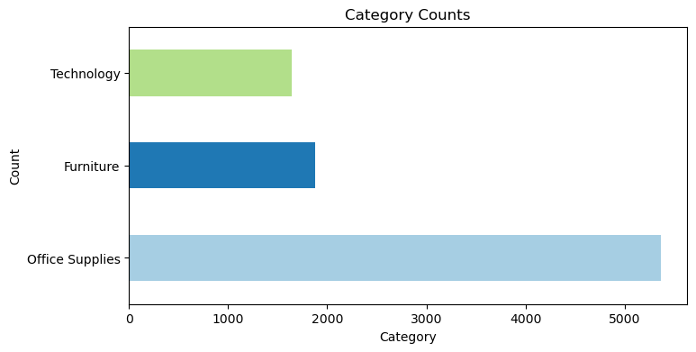

```python
# Write your code here (7.2 Create a bar chart horizontal to demonstrate the count of unique categories)
category_count = superstore_order["Category"].value_counts()
plt.figure(figsize=(8, 4))
category_count.plot(kind='barh', color=plt.cm.Paired.colors)
plt.title("Category Counts")
plt.xlabel("Category")
plt.ylabel("Count")
plt.show()
```

```python
# Write your code here (7.3 Compute the ratio of these categories in percentage and print the results)
category_count = pd.DataFrame(category_count)
category_count['ratio'] = category_count['count'] / category_count['count'].sum() * 100
category_count
```

| Category | count | ratio |
| --- | --- | --- |
| Office Supplies | 5360 | 60.360360 |
| Furniture | 1880 | 21.171171 |
| Technology | 1640 | 18.468468 |

8. Update the type of all columns that contain dates to *datetime* and show information after an update.
- Order Date, Ship Date

```python
superstore_order.head(5)
```

|  | Row ID | Order ID | Order Date | Ship Date | Ship Mode | Customer ID | Customer Name | Segment | Country | City | ... | Postal Code | Region | Product ID | Category | Sub-Category | Product Name | Sales | Quantity | Discount | Profit |
| --- | --- | --- | --- | --- | --- | --- | --- | --- | --- | --- | --- | --- | --- | --- | --- | --- | --- | --- | --- | --- | --- |
| 0 | 1 | CA-2016-152156 | 08/11/2016 | 11/11/2016 | Second Class | CG-12520 | Claire Gute | Consumer | United States | Henderson | ... | 42420 | South | FUR-BO-10001798 | Furniture | Bookcases | Bush Somerset Collection Bookcase | 261.9600 | 2 | 0.00 | 41.9136 |
| 1 | 2 | CA-2016-152156 | 08/11/2016 | 11/11/2016 | Second Class | CG-12520 | Claire Gute | Consumer | United States | Henderson | ... | 42420 | South | FUR-CH-10000454 | Furniture | Chairs | Hon Deluxe Fabric Upholstered Stacking Chairs ... | 731.9400 | 3 | 0.00 | 219.5820 |
| 2 | 3 | CA-2016-138688 | 12/06/2016 | 16/06/2016 | Second Class | DV-13045 | Darrin Van Huff | Corporate | United States | Los Angeles | ... | 90036 | West | OFF-LA-10000240 | Office Supplies | Labels | Self-Adhesive Address Labels for Typewriters b... | 14.6200 | 2 | 0.00 | 6.8714 |
| 3 | 4 | US-2015-108966 | 11/10/2015 | 18/10/2015 | Standard Class | SO-20335 | Sean ODonnell | Consumer | United States | Fort Lauderdale | ... | 33311 | South | FUR-TA-10000577 | Furniture | Tables | Bretford CR4500 Series Slim Rectangular Table | 957.5775 | 5 | 0.45 | -383.0310 |
| 4 | 5 | US-2015-108966 | 11/10/2015 | 18/10/2015 | Standard Class | SO-20335 | Sean ODonnell | Consumer | United States | Fort Lauderdale | ... | 33311 | South | OFF-ST-10000760 | Office Supplies | Storage | Eldon Fold N Roll Cart System | 22.3680 | 2 | 0.20 | 2.5164 |

5 rows × 21 columns

```python
superstore_order[['Order Date', 'Ship Date']].info()
```

```
<class 'pandas.core.frame.DataFrame'>
RangeIndex: 8880 entries, 0 to 8879
Data columns (total 2 columns):
 #   Column      Non-Null Count  Dtype
---  ------      --------------  -----
 0   Order Date  8880 non-null   object
 1   Ship Date   8880 non-null   object
dtypes: object(2)
memory usage: 138.9+ KB
```

```python
# write your code here
for col in ['Order Date', 'Ship Date']:
    superstore_order[col] = pd.to_datetime(superstore_order[col], format='%d/%m/%Y')

superstore_order[['Order Date', 'Ship Date']].info()
```

```
<class 'pandas.core.frame.DataFrame'>
RangeIndex: 8880 entries, 0 to 8879
Data columns (total 2 columns):
 #   Column      Non-Null Count  Dtype
---  ------      --------------  -----
 0   Order Date  8880 non-null   datetime64[ns]
 1   Ship Date   8880 non-null   datetime64[ns]
dtypes: datetime64[ns](2)
memory usage: 138.9 KB
```

9. Create a new column "Processing time day" to show number of days taken to ship an order and show your result in a dataframe format.

*Hint: The duration starts as soon as the item has been ordered and ends once the order has successfully shipped.*

```python
# write your code here
superstore_order["Processing time day"] = (superstore_order["Ship Date"] - superstore_order["Order Date"]).dt.days
superstore_order[['Order Date', 'Ship Date', 'Processing time day']].head()
```

|  | Order Date | Ship Date | Processing time day |
| --- | --- | --- | --- |
| 0 | 2016-11-08 | 2016-11-11 | 3 |
| 1 | 2016-11-08 | 2016-11-11 | 3 |
| 2 | 2016-06-12 | 2016-06-16 | 4 |
| 3 | 2015-10-11 | 2015-10-18 | 7 |
| 4 | 2015-10-11 | 2015-10-18 | 7 |

10. Based on the result in 9.
- 10.1 How many orders are there that take more than 5 days to process?
- 10.2 Show the top 5 rows (expected output should contain these columns: Order ID, Order Date, Ship Date, Processing time day, Quantity)
- 10.3 Plot the histogram based on the column Quantity

*Note: please create additional cells to answer 10.2 - 10.3*

```python
# Write your code here (10.1)
count = (superstore_order["Processing time day"] > 5).sum()
print(count)
```

```
1656
```

```python
# Write your code here (10.2)
cols = ["Order ID", "Order Date", "Ship Date", "Processing time day", "Quantity"]
superstore_order[cols].head(5)
```

|  | Order ID | Order Date | Ship Date | Processing time day | Quantity |
| --- | --- | --- | --- | --- | --- |
| 0 | CA-2016-152156 | 2016-11-08 | 2016-11-11 | 3 | 2 |
| 1 | CA-2016-152156 | 2016-11-08 | 2016-11-11 | 3 | 3 |
| 2 | CA-2016-138688 | 2016-06-12 | 2016-06-16 | 4 | 2 |
| 3 | US-2015-108966 | 2015-10-11 | 2015-10-18 | 7 | 5 |
| 4 | US-2015-108966 | 2015-10-11 | 2015-10-18 | 7 | 2 |

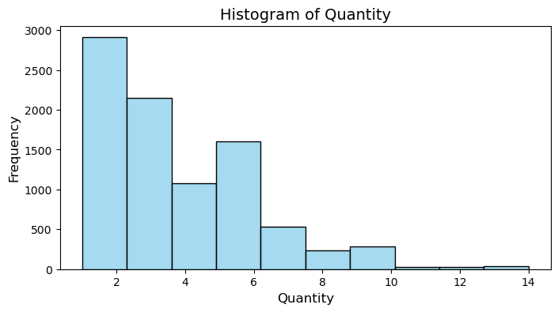

```python
# Write your code here (10.3)
plt.figure(figsize=(8, 4))
sns.histplot(superstore_order["Quantity"], bins=10, color="skyblue")

plt.xlabel("Quantity", fontsize=12)
plt.ylabel("Frequency", fontsize=12)
plt.title("Histogram of Quantity", fontsize=14)
plt.show()
```

11. Total sales compare across different regions
- 11.1 Create a bar chart to visualize.

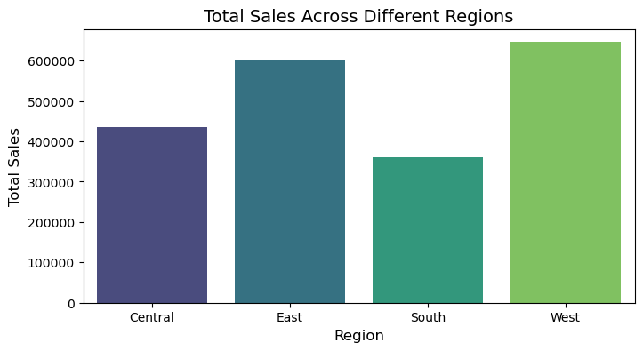

```python
# Write your code here (11.1)
sales_by_region = superstore_order.groupby("Region")["Sales"].sum().reset_index()

plt.figure(figsize=(8, 4))
sns.barplot(data=sales_by_region, x="Region", y="Sales", hue='Region', palette='viridis')
plt.xlabel("Region", fontsize=12)
plt.ylabel("Total Sales", fontsize=12)
plt.title("Total Sales Across Different Regions", fontsize=14)
plt.show()
```

- 11.2 How do total sales compare across different regions? Explain in as much detail as possible.

  Ans: ยอดขายรวมเรียงลำดับภูมิภาคจากมากไปน้อยได้ดังนี้ West, East, Central, South

12.Which states have the highest number of returns? Use a horizontal bar chart.

Ans: California

```python
# Write your code here (12)
merged_df = pd.merge(superstore_return, superstore_order, on='Order ID', how='inner')
filtered_df = merged_df[ merged_df['Returned'] == 'Yes' ]
return_by_state = filtered_df.groupby('State').agg({'Returned': 'count'})\
                                .sort_values(by='Returned', ascending=False).reset_index()
return_by_state
```

|  | State | Returned |
| --- | --- | --- |
| 0 | California | 298 |
| 1 | Washington | 60 |
| 2 | New York | 59 |
| 3 | Texas | 30 |
| 4 | Colorado | 25 |
| 5 | Ohio | 24 |
| 6 | Arizona | 22 |
| 7 | Oregon | 18 |
| 8 | Illinois | 18 |
| 9 | Pennsylvania | 16 |
| 10 | Tennessee | 14 |
| 11 | Utah | 12 |
| 12 | Florida | 11 |
| 13 | Massachusetts | 11 |
| 14 | Delaware | 10 |
| 15 | Michigan | 9 |
| 16 | Georgia | 9 |
| 17 | North Carolina | 8 |
| 18 | Maryland | 7 |
| 19 | Virginia | 6 |
| 20 | Mississippi | 5 |
| 21 | Kentucky | 4 |
| 22 | Oklahoma | 4 |
| 23 | New Hampshire | 3 |
| 24 | New Jersey | 3 |
| 25 | New Mexico | 3 |
| 26 | Indiana | 3 |
| 27 | Rhode Island | 2 |
| 28 | Alabama | 2 |
| 29 | Montana | 2 |
| 30 | Minnesota | 2 |
| 31 | Idaho | 2 |
| 32 | Wisconsin | 2 |
| 33 | Nebraska | 1 |
| 34 | Missouri | 1 |
| 35 | Louisiana | 1 |

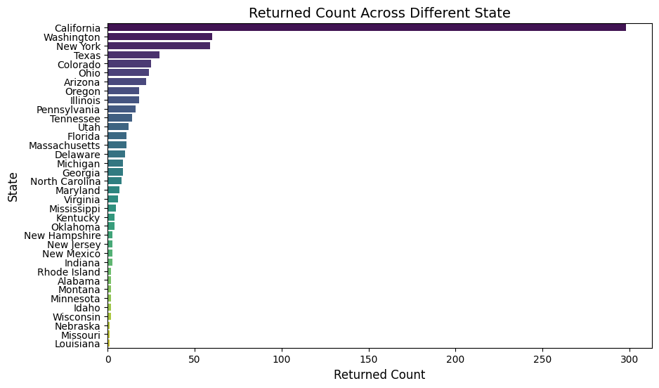

```python
plt.figure(figsize=(10, 6))
sns.barplot(data=return_by_state, x='Returned', y='State', hue='State', palette='viridis')
plt.xlabel('Returned Count', fontsize=12)
plt.ylabel('State', fontsize=12)
plt.title('Returned Count Across Different State', fontsize=14)
plt.show()
```

13. What is the correlation between numerical variables in the superstore_order dataset? Use a heatmap

*Hint: Use seaborn to create a heatmap :)*

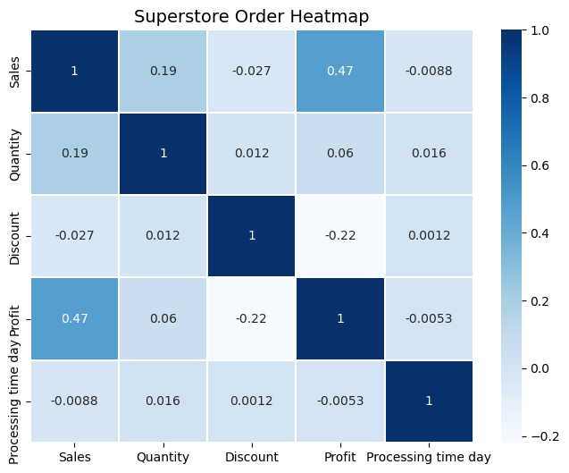

```python
# Write your code here (13)
cols = ['Sales', 'Quantity', 'Discount', 'Profit','Processing time day']
# คำนวณ correlation matrix
correlation_matrix = superstore_order[cols].corr()
# สร้าง heatmap
plt.figure(figsize=(8, 6))
sns.heatmap(correlation_matrix, cmap='Blues', linewidths=0.30, annot=True)
plt.title('Superstore Order Heatmap', fontsize=14)
plt.show()
```

14. Create a USA State-Level to visualize total sales per state.
- The darkest color represents the highest total sales.
- The lightest color represents the lowest total sales.
- Use a continuous gradient scale (e.g., dark blue to light blue, dark red to light red, or any custom gradient of your choice).

*Hint: Use plotly.express*

```python
state_code = pd.read_csv('https://raw.githubusercontent.com/plotly/datasets/master/2011_us_ag_exports.csv')
us_state_map = state_code[['code', 'state']]

states_dict = {}
for i, row in us_state_map.iterrows():
    states_dict[row['state']] = row['code']
print(states_dict)
```

[output not shown]

```python
sales_per_state = superstore_order.groupby('State')['Sales'].sum().reset_index()
sales_per_state['code'] = sales_per_state['State'].map(states_dict)

# Create the choropleth map using Plotly
px.choropleth(sales_per_state,
                    locations='code',
                    locationmode='USA-states',
                    color='Sales',
                    color_continuous_scale="Reds",
                    labels={'Sales': 'Total Sales'},
                    title='Total Sales per State in the USA',
                    scope='usa')
```

[output not shown]

14.2 Answer the following questions:

1. Which state has the highest total sales?
2. How do sales anomalies affect the gradient color shading on the map?
3. If you change the color scale, does it impact readability? Why or why not?

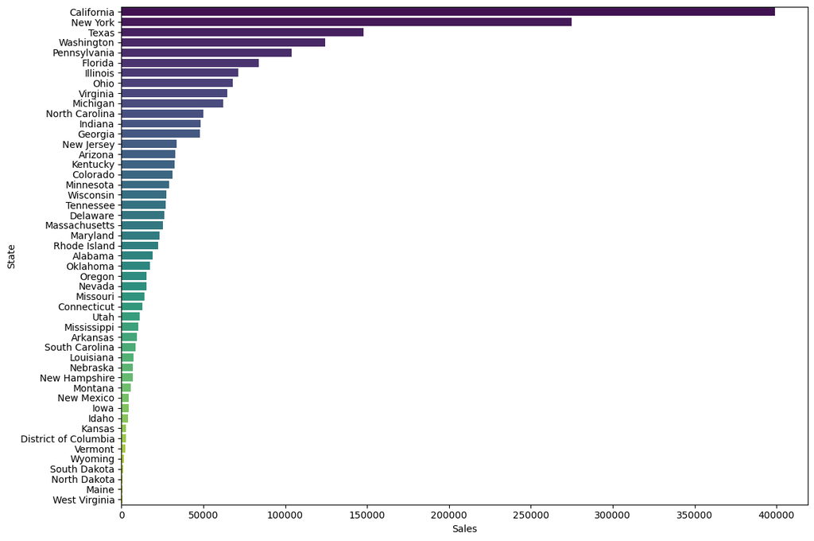

```python
sorted_sales = sales_per_state.sort_values(by='Sales', ascending=False).reset_index(drop=True)

plt.figure(figsize=(12, 8))
sns.barplot(data=sorted_sales, y='State', x='Sales', hue='State', palette='viridis')
plt.tight_layout()
plt.show()
```

```python
px.choropleth(sales_per_state,
                    locations='code',
                    locationmode='USA-states',
                    color='Sales',
                    color_continuous_scale="Reds",
                    range_color=(0, 80000),
                    labels={'Sales': 'Total Sales'},
                    title='Total Sales per State in the USA',
                    scope='usa')
```

[output not shown]

15. Create a box plot to compare the different shipping modes based on total profit.

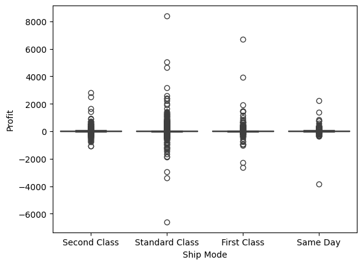

```python
#Write your code here (15)
sns.boxplot(data=superstore_order, x='Ship Mode', y='Profit')
```

15.2 Which shipping mode has the highest median profit?

Ans: Second Class

```python
superstore_order.groupby('Ship Mode').agg({'Profit': 'median'})\
    .sort_values('Profit', ascending=False)\
    .rename(columns={'Profit': 'Median Profit'})
```

| Ship Mode | Median Profit |
| --- | --- |
| Second Class | 9.76080 |
| First Class | 8.79255 |
| Same Day | 8.43490 |
| Standard Class | 8.31040 |

[BONUS 20 pts] Determine the percentage of customers who:

- B1)returned the product once
- B2) returned the product at least once
- B3) never returned the product
- Finally, Plot a comparison of B2 and B3

*Note: please create additional cells to answer the above points*

B1

- Everyone in superstore_return.csv returned the product so, we don't have to filter the 'Returned' value.

```python
superstore_return['Returned'].unique()
```

```
array(['Yes'], dtype=object)
```

```python
merged_df = pd.merge(superstore_order, superstore_return, how='left', on='Order ID')
merged_df.head()
```

|  | Row ID | Order ID | Order Date | Ship Date | Ship Mode | Customer ID | Customer Name | Segment | Country | City | ... | Product ID | Category | Sub-Category | Product Name | Sales | Quantity | Discount | Profit | Processing time day | Returned |
| --- | --- | --- | --- | --- | --- | --- | --- | --- | --- | --- | --- | --- | --- | --- | --- | --- | --- | --- | --- | --- | --- |
| 0 | 1 | CA-2016-152156 | 2016-11-08 | 2016-11-11 | Second Class | CG-12520 | Claire Gute | Consumer | United States | Henderson | ... | FUR-BO-10001798 | Furniture | Bookcases | Bush Somerset Collection Bookcase | 261.9600 | 2 | 0.00 | 41.9136 | 3 | NaN |
| 1 | 2 | CA-2016-152156 | 2016-11-08 | 2016-11-11 | Second Class | CG-12520 | Claire Gute | Consumer | United States | Henderson | ... | FUR-CH-10000454 | Furniture | Chairs | Hon Deluxe Fabric Upholstered Stacking Chairs ... | 731.9400 | 3 | 0.00 | 219.5820 | 3 | NaN |
| 2 | 3 | CA-2016-138688 | 2016-06-12 | 2016-06-16 | Second Class | DV-13045 | Darrin Van Huff | Corporate | United States | Los Angeles | ... | OFF-LA-10000240 | Office Supplies | Labels | Self-Adhesive Address Labels for Typewriters b... | 14.6200 | 2 | 0.00 | 6.8714 | 4 | NaN |
| 3 | 4 | US-2015-108966 | 2015-10-11 | 2015-10-18 | Standard Class | SO-20335 | Sean ODonnell | Consumer | United States | Fort Lauderdale | ... | FUR-TA-10000577 | Furniture | Tables | Bretford CR4500 Series Slim Rectangular Table | 957.5775 | 5 | 0.45 | -383.0310 | 7 | NaN |
| 4 | 5 | US-2015-108966 | 2015-10-11 | 2015-10-18 | Standard Class | SO-20335 | Sean ODonnell | Consumer | United States | Fort Lauderdale | ... | OFF-ST-10000760 | Office Supplies | Storage | Eldon Fold N Roll Cart System | 22.3680 | 2 | 0.20 | 2.5164 | 7 | NaN |

5 rows × 23 columns

```python
# count method automatically handle null and doesn't count it
returnByCustomer = merged_df.groupby('Customer ID').agg({'Returned': 'count'})
return_once = len(returnByCustomer[ returnByCustomer['Returned'] == 1 ])
ratio = round(return_once / len(returnByCustomer) * 100, 2)

print('Returned once customer count:', return_once)
print('Returned once ratio:', ratio, '%')
```

```
Returned once customer count: 62
Returned once ratio: 7.86 %
```

B2

```python
return_count = len(returnByCustomer[ returnByCustomer['Returned'] >= 1 ])
ratio = round(return_count / len(returnByCustomer) * 100, 2)

print('Returned at least once customer count:', return_count)
print('Returned at least once ratio:', ratio, '%')
```

```
Returned at least once customer count: 222
Returned at least once ratio: 28.14 %
```

B3

```python
no_return = len(returnByCustomer[ returnByCustomer['Returned'] == 0 ])
ratio = round(no_return / len(returnByCustomer) * 100, 2)

print('No returned customer count:', no_return)
print('No returned ratio:', round(no_return / len(returnByCustomer) * 100, 2), '%')
```

```
No returned customer count: 567
No returned ratio: 71.86 %
```